# More EDA

Daniel Lawson

Block 01.3.2

# Exploratory Data Analysis (EDA)

EDA is a critical part of every data science project. It is the process of understanding the data, and its limitations, before you start to model it. We’ll focus on simple counts and summaries, and then start “grokking” relationships in the data through cross-tabulation which we’ll structure for visualisation.

You should have already run the introductory 01.3-WSL-1-EDA.Rmd worksheet and become familiar with working with an RStudio RMarkdown document.

# 0.0 Requirements

Its good practice to get the requirements right at the top. The following solution checks for the requirements, and then installs them if they are not present.

```r
if(!require("gplots")) install.packages("gplots")
```

[output not shown]

```r
if(!require("readr")) install.packages("readr")
```

```r
library("gplots")
library("readr")
```

# 1.0 DATA

Here we’re going to go a little further and explore a new dataset, the [KDD99](http://kdd.ics.uci.edu/databases/kddcup99/kddcup99.html) dataset. Read about the competition [task specification](http://kdd.ics.uci.edu/databases/kddcup99/task.html).

We use the [10%](http://kdd.org/cupfiles/KDDCupData/1999/kddcup.data_10_percent.zip) and [column names](http://kdd.org/cupfiles/KDDCupData/1999/kddcup.names) files, which you can download directly. We use the opportunity of exploring **external data** to make some suggestions for your group assessment project structure.

Q: What information would be useful here? What would you like to see in an exemplar web resource?

### Notes on the data

Cyber security data is often very weird. These data were generated in a competition setting where teams were hacking one another. The connection activity was then recorded on the internet connection, classified by what generated that traffic, and turned into “features”, i.e. a data frame. Because the computers are “doing something” all the time, there is “normal” traffic in here, but there is a very large number of “cyber attack” related traffic, which is unrealistic of real data. Also the ability to classify everything your computer is doing to obtain “true labels” is unusual.

The details are very involved but all we really care about is that there are some labels, and our task as data scientists is to see whether the classification task of identifying attacks is feasible.

## 1.1 Data Import

**DATA ORGANISATION**: It is very helpful to keep the project structure that I use, so your code “just runs”. Therefore work in a directory (“workshops”) and keep your data in a directory called “data” in the PARENT DIRECTORY, e.g. both inside “dst”, so that your file structure looks like this:

- dst
  - dst/data
  - dst/workshops

. This maps better to how we will structure the Assessments, which are fussier again because of their group project nature.

**OBTAINING DATA**: It is essential that it is clear how to obtain the data used in an analysis. It is OK to have manual steps if they are clearly described, but automation is best.

To automate this, DIFFERENTLY AND BETTER THAN THE RECORDING, we will use internal R functions which work regardless of file system. We would like a cross-platform (Windows/Linux/Mac) solution, and this is provided by the `file.path` function in R, rather than specifying folder locations completely. For example, Windows would use `..\\data\\file`, whereas Mac/Linux would be `../data/file`. Run `?file.path` to learn more.

This could look like this:

```r
if(!dir.exists(file.path("..","data"))) dir.create(file.path("..","data"))
if(!file.exists(file.path("..","data","kddcup.data_10_percent.zip"))) download.file("http://kdd.org/cupfiles/KDDCupData/1999/kddcup.data_10_percent.zip", destfile=file.path("..","data","kddcup.data_10_percent.zip"))
if(!file.exists(file.path("..","data","kddcup.names"))) download.file("http://kdd.org/cupfiles/KDDCupData/1999/kddcup.names",destfile=file.path("..","data","kddcup.names"))
```

Aside: An even better implementation would define, or find, a function like `safedircreate`, along the lines of:

```r
safedircreate<-function(...)
  if(!dir.exists(file.path(...))) dir.create(file.path(...))
```

This could be used as part of a `safedownloadfile` function, etc so that we only ever specify the location once. The above function is used as `safedircreate("..","data")` in this context.

Q: When should you implement this? Can you do it so that it is reusable for your assessments?

Code checking question: is this guaranteed to always work? What would make this completely robust? Does R provide that tool already?

#### See Question Q1 in Block 1 Portfolio

about how to generate data.

## 1.2 Exploratory Data Analysis (1D)

The data are read in as follows:

```r
kddata<-as.data.frame(read_csv(file.path("..","data","kddcup.data_10_percent.zip"),col_names=FALSE)) ## Ignore the warnings - there is a bug with the header
```

```
## Warning: One or more parsing issues, call `problems()` on your data frame for details,
## e.g.:
##   dat <- vroom(...)
##   problems(dat)
```

```r
kddnames=read.table(file.path("..","data","kddcup.names"),sep=":",skip=1,as.is=T)
colnames(kddata)=c(kddnames[,1],"normal") # here we fix the bug with the header
goodcat=names(which(table(kddata[,"normal"])>1))
kddata=kddata[kddata[,"normal"]%in%goodcat,]
```

Q: How important are these problems? What should we do about them? If we wanted to stop this warning, or all warnings, how would we do it? And when should we?

Lets take a look:

```r
head(kddata)
```

```
##   duration protocol_type service flag src_bytes dst_bytes land wrong_fragment
## 1        0           tcp    http   SF       181      5450    0              0
## 2        0           tcp    http   SF       239       486    0              0
## 3        0           tcp    http   SF       235      1337    0              0
## 4        0           tcp    http   SF       219      1337    0              0
## 5        0           tcp    http   SF       217      2032    0              0
## 6        0           tcp    http   SF       217      2032    0              0
##   urgent hot num_failed_logins logged_in num_compromised root_shell
## 1      0   0                 0         1               0          0
## 2      0   0                 0         1               0          0
## 3      0   0                 0         1               0          0
## 4      0   0                 0         1               0          0
## 5      0   0                 0         1               0          0
## 6      0   0                 0         1               0          0
##   su_attempted num_root num_file_creations num_shells num_access_files
```

[output cut: 48 more lines]

And get a summary of the data:

```r
summary(kddata)
```

```
##     duration          protocol_type         service              flag
##  Min.   :    0.00   Length   :494020   Length   :494020   Length   :494020
##  1st Qu.:    0.00   N.unique :     3   N.unique :    66   N.unique :    11
##  Median :    0.00   N.blank  :     0   N.blank  :     0   N.blank  :     0
##  Mean   :   47.98   Min.nchar:     3   Min.nchar:     3   Min.nchar:     2
##  3rd Qu.:    0.00   Max.nchar:     4   Max.nchar:    11   Max.nchar:     6
##  Max.   :58329.00
##    src_bytes           dst_bytes              land           wrong_fragment
##  Min.   :        0   Min.   :      0.0   Min.   :0.000e+00   Min.   :0.000000
##  1st Qu.:       45   1st Qu.:      0.0   1st Qu.:0.000e+00   1st Qu.:0.000000
##  Median :      520   Median :      0.0   Median :0.000e+00   Median :0.000000
##  Mean   :     3026   Mean   :    868.5   Mean   :4.453e-05   Mean   :0.006433
##  3rd Qu.:     1032   3rd Qu.:      0.0   3rd Qu.:0.000e+00   3rd Qu.:0.000000
##  Max.   :693375640   Max.   :5155468.0   Max.   :1.000e+00   Max.   :3.000000
##      urgent               hot           num_failed_logins     logged_in
##  Min.   :0.000e+00   Min.   : 0.00000   Min.   :0.0000000   Min.   :0.0000
##  1st Qu.:0.000e+00   1st Qu.: 0.00000   1st Qu.:0.0000000   1st Qu.:0.0000
##  Median :0.000e+00   Median : 0.00000   Median :0.0000000   Median :0.0000
##  Mean   :1.417e-05   Mean   : 0.03452   Mean   :0.0001518   Mean   :0.1482
##  3rd Qu.:0.000e+00   3rd Qu.: 0.00000   3rd Qu.:0.0000000   3rd Qu.:0.0000
##  Max.   :3.000e+00   Max.   :30.00000   Max.   :5.0000000   Max.   :1.0000
##  num_compromised       root_shell         su_attempted
##  Min.   :  0.00000   Min.   :0.0000000   Min.   :0.000e+00
##  1st Qu.:  0.00000   1st Qu.:0.0000000   1st Qu.:0.000e+00
##  Median :  0.00000   Median :0.0000000   Median :0.000e+00
##  Mean   :  0.01021   Mean   :0.0001113   Mean   :3.644e-05
##  3rd Qu.:  0.00000   3rd Qu.:0.0000000   3rd Qu.:0.000e+00
##  Max.   :884.00000   Max.   :1.0000000   Max.   :2.000e+00
##     num_root         num_file_creations    num_shells        num_access_files
##  Min.   :  0.00000   Min.   : 0.000000   Min.   :0.0000000   Min.   :0.000000
##  1st Qu.:  0.00000   1st Qu.: 0.000000   1st Qu.:0.0000000   1st Qu.:0.000000
##  Median :  0.00000   Median : 0.000000   Median :0.0000000   Median :0.000000
##  Mean   :  0.01135   Mean   : 0.001083   Mean   :0.0001093   Mean   :0.001008
##  3rd Qu.:  0.00000   3rd Qu.: 0.000000   3rd Qu.:0.0000000   3rd Qu.:0.000000
##  Max.   :993.00000   Max.   :28.000000   Max.   :2.0000000   Max.   :8.000000
##  num_outbound_cmds is_host_login is_guest_login         count
##  Min.   :0         Min.   :0     Min.   :0.000000   Min.   :  0.0
##  1st Qu.:0         1st Qu.:0     1st Qu.:0.000000   1st Qu.:117.0
##  Median :0         Median :0     Median :0.000000   Median :510.0
##  Mean   :0         Mean   :0     Mean   :0.001387   Mean   :332.3
```

[output cut: 29 more lines]

```
##  Max.   :1.00000        Max.   :1.0000              Max.   :1.000000
##  dst_host_serror_rate dst_host_srv_serror_rate dst_host_rerror_rate
##  Min.   :0.0000       Min.   :0.0000           Min.   :0.00000
##  1st Qu.:0.0000       1st Qu.:0.0000           1st Qu.:0.00000
##  Median :0.0000       Median :0.0000           Median :0.00000
##  Mean   :0.1768       Mean   :0.1764           Mean   :0.05812
##  3rd Qu.:0.0000       3rd Qu.:0.0000           3rd Qu.:0.00000
##  Max.   :1.0000       Max.   :1.0000           Max.   :1.00000
##  dst_host_srv_rerror_rate       normal
##  Min.   :0.00000          Length   :494020
##  1st Qu.:0.00000          N.unique :    23
##  Median :0.00000          N.blank  :     0
##  Mean   :0.05741          Min.nchar:     4
##  3rd Qu.:0.00000          Max.nchar:    16
##  Max.   :1.00000
```

Q: What can you “understand” about the data from this? What is worrying about it?

We need to pay attention to variables that:

- are not numeric
- Have surprising or large ranges, where the choice of linear scale may be inappropriate
- Don’t vary much or at all

## Activity 1: EDA for the “normal” class label

The $Y$ value is a multiple-category label called “normal” in the data. This is the attack type, with value “normal” being “not an attack” and everything else being an attack.

Q: How did I know this? How would you find it out from the data source?

- We will make a barplot of the “normal” column, using an appropriate scaling.
- Use the inline help (?par).
- Consider the scaling of the “y” axis.

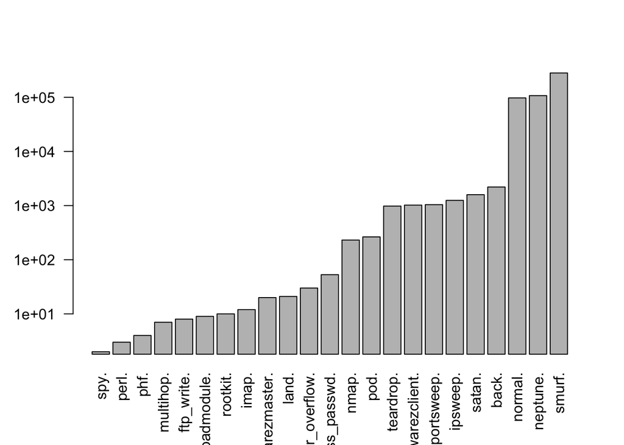

```r
par(las=2) # Ask R to plot perpendicular to the axes
barplot((sort(table(kddata[,"normal"]))),log="y") # Log axis
```

Now we’ll examine the labels separately. This is a way to make a list for each class:

```r
labs=unique(as.character(kddata[,"normal"]))
names(labs)=labs
kddlist=lapply(labs,function(x){
  kddata[kddata[,"normal"]==x,1:41]
})
```

The Tidyverse data objects have nice ways to examine these sorts of conditional statements.

Q: What does `lapply` do here? What sort of object is kddlist? Is this what we want?

## Activity 2: Heatmap of the mean for each variable within each category

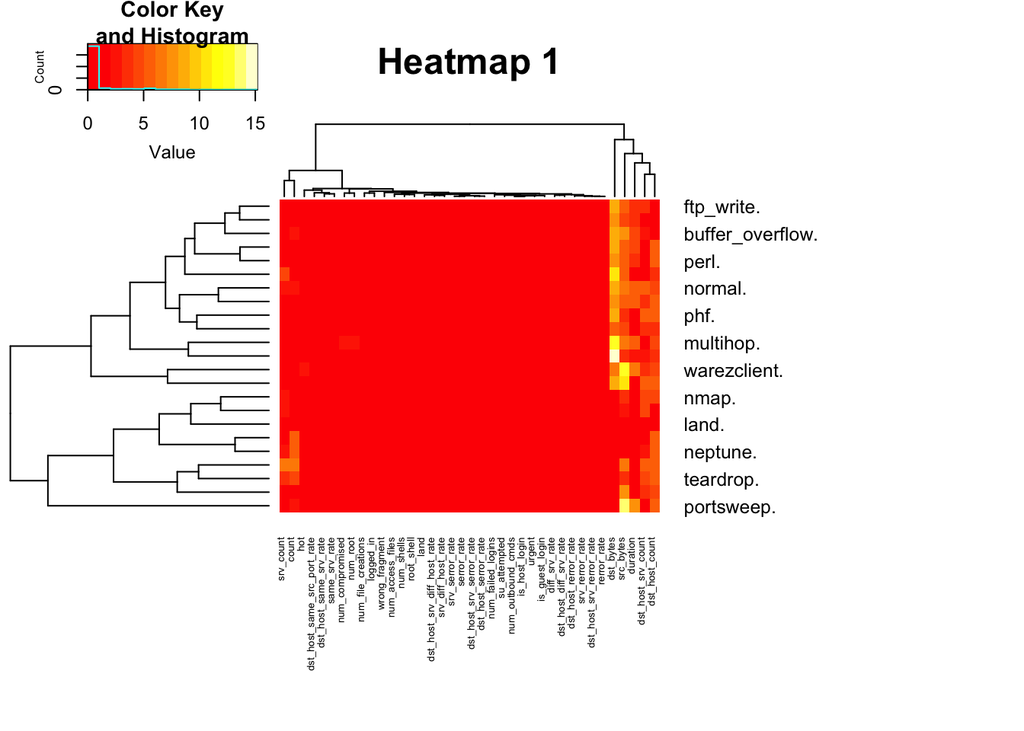

```r
kddmean=t(sapply(kddlist,function(x)colMeans(x[,c(1,5:41)])))
library("gplots")
heatmap.2(log(kddmean+1),margins =c(9,15),trace="none",cexCol = 0.5,main="Heatmap 1")
```

```r
mycols=c("dst_bytes","src_bytes","duration","dst_host_svd_count","dst_host_count","srv_count","count")
```

Q: What sort of objects are `kddmean` and `kddlist`? Why? Q: Why has `trace="none"` been passed into heatmap.2? How do we find out what it does? Q: What is the “+1” doing in the log?

We can obtain the top 7 features by their variance across the classes in this plot using:

```r
head(sort(apply(log(kddmean+1),2,var),decreasing=TRUE),7)
```

```
##          dst_bytes          src_bytes           duration              count
##          23.008924          11.836058           6.249263           3.177224
##     dst_host_count dst_host_srv_count          srv_count
##           2.749490           2.453298           2.177616
```

Q: What does high variance for a feature mean? How might it be important for downstream work?

Now we want to standardize the features and repeat the *heatmap*.

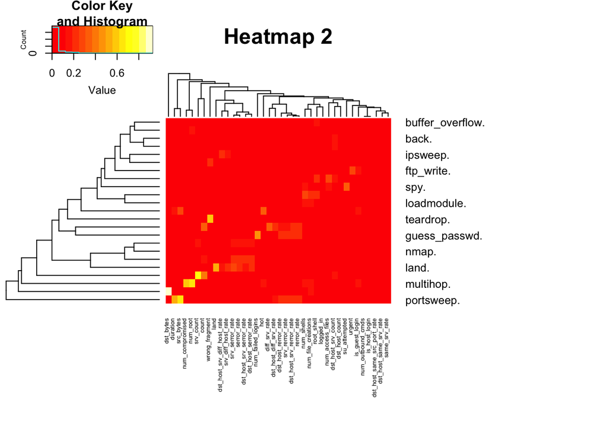

```r
kddfreq=apply(kddmean,2,function(x)x/(sum(x)+1)) ## Divide each column ()
kddfreq[!is.finite(kddfreq)]=0
kddfreq[is.nan(kddfreq)]=0
heatmap.2(kddfreq,margins =c(9,15),trace="none",cexCol = 0.5,main="Heatmap 2")
```

Q: What is this standardization? What is the “+1” doing in the frequency calculation? (We cover this later in the course)

The corresponding variance in the features for this heatmap is:

```r
head(sort(apply(kddfreq,2,var),decreasing=TRUE),7)
```

```
##       dst_bytes       src_bytes       srv_count        num_root  wrong_fragment
##      0.03716260      0.02113590      0.02079709      0.01753651      0.01692405
## num_compromised        duration
##      0.01373042      0.01309468
```

#### See Question Q2 in Block 1 Portfolio

about what these results mean.

## Activity 3: Comparison for the categorical variables

We will now make a *table* of the interaction between the class label and the *categorical* variables.

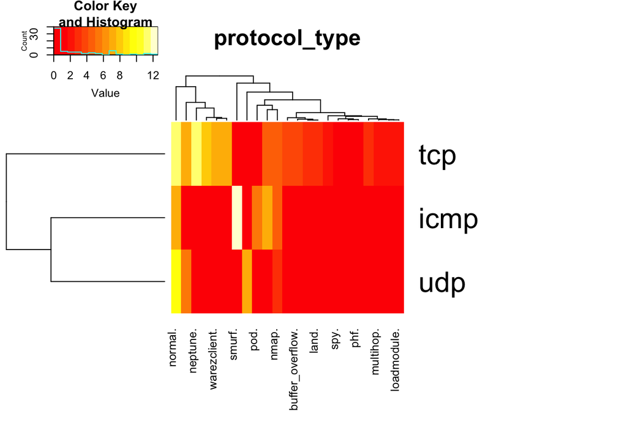

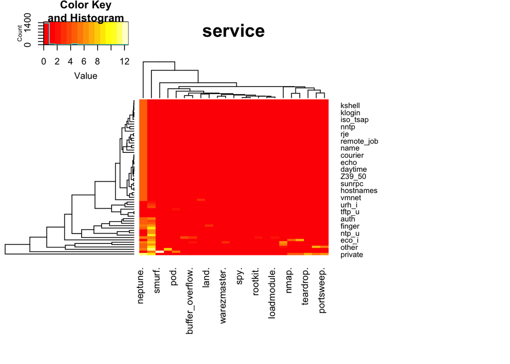

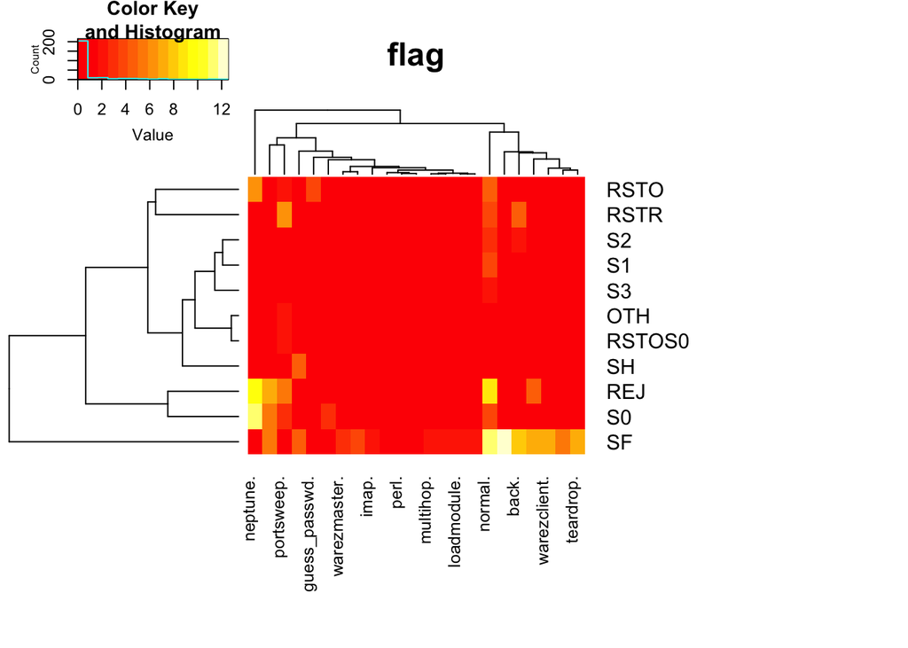

```r
mycategorical=colnames(kddata)[2:4]
classlist=lapply(mycategorical,function(mycat){
  table(kddata[,c(mycat,"normal")])
})
for(i in 1:3) heatmap.2(log(classlist[[i]]+1),margins =c(9,15),trace="none",main=mycategorical[i])
```

Q: Some things to reflect on:

- What about scale here? Explore different choices of scaling function.
- Describe some key features that you see in the data.
- Are any of the classes *informative*?
- In what sense are they informative?

## Activity 4: Variability

- We want to learn about the *variability* in the labels with the function “sd”, given the mean.
- For that we must *represent* variability in an appropriate format.
- It is again convenient to construct the matrices that we want to plot.

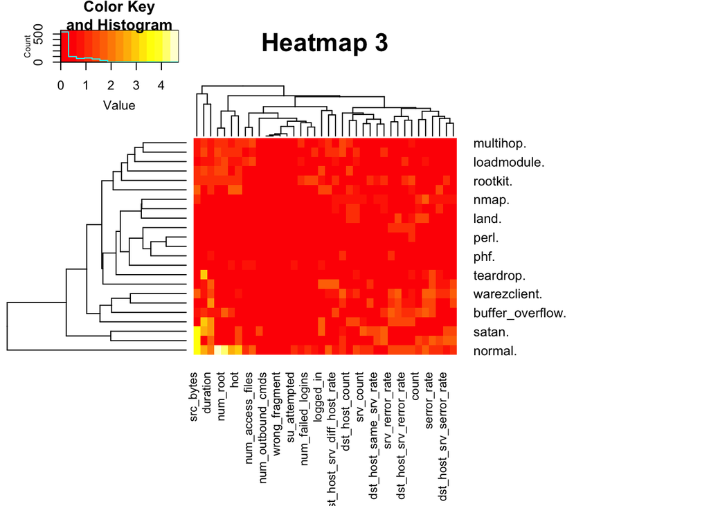

```r
kddsd=t(sapply(kddlist,function(x){
  apply(x[,c(1,5:41)],2,sd)
}))
heatmap.2(log(kddsd/(kddmean+0.01)+1),margins =c(9,15),trace="none",main="Heatmap 3")
```

Q: Some reflection:

- Again, what interpretations can you make about the data?
- What would happen if we do not scale the s.d. to the individual mean entry?
- What if we use a linear instead of a log scale?
- Is high variability good, or bad, for inference?

#### See Question Q3 in Block 1 Portfolio

about what these results mean.

## Activity 5: Final thoughts and reflection

Q: Some final thoughts:

- The dataset contains attacks that are not listed here.
- Consider what the above Exploratory Data analysis might mean for the hopes of detecting different properties of attack.
- How you might go about making a model that will perform well out-of-sample, *comparing* “normal” to other classes of “attack”?
- You might choose to explore this further in Assessment 0.